# Multiverse Table Creation

Way too many ways to make a table these days

Richard Evans Richard.Evans8@va.gov

2021-12-17

# Rationale

In this tutorial I will go through *so* many ways to make tables in R, Rstudio, and RMarkdown, and yet, it probably will not be exhaustive. Methods in this tutorial:

- Multipurpose
  - [arsenal](https://cran.r-project.org/web/packages/arsenal/index.html)
  - [tableone](https://cran.r-project.org/web/packages/tableone/vignettes/introduction.html)
  - [gt](https://gt.rstudio.com/articles/intro-creating-gt-tables.html)
  - [gtsummary](http://www.danieldsjoberg.com/gtsummary/)
  - [flextable](https://davidgohel.github.io/flextable/articles/offcran/examples.html)
  - [ttt](https://cran.r-project.org/web/packages/ttt/vignettes/ttt-intro.html)
- Model Summary Tables
  - gtsummary
  - [jtools](https://cran.r-project.org/web/packages/jtools/vignettes/summ.html)
  - [sjPlot](https://cran.r-project.org/web/packages/sjPlot/vignettes/tab_model_estimates.html)
  - [finalfit](https://cran.r-project.org/web/packages/finalfit/vignettes/finalfit.html)
- DIY

I’ll be making use of some data from one of Dr. Erika Sears’ Studies, sans any identifiable data, of course.

The first step in this document is to explain the data we’ll be using, and setting it up for analysis, skip down to the tables section.

# Data

## Source

A retrospective cohort study of Veterans undergoing Carpal Tunnel Release (CTR) procedures from January 1, 2010 to December 31, 2016.

## Cohort Inclusion

- Veteran has a primary care physician within the Veterans Administration
- First CTR (not re-do CTR)

## Exclusion

- Concurrent procedures
- Last PCP visit to CTR > 7 years (outliers)

## Study Variables

- Explanatory
  - Patient-level
    - Age at index CTS (Consider non-linear relationship)
    - Sex
    - Race
    - Ethnicity
    - Charlson Comorbidity Index
    - Diabetes
    - VA Priority Group (if service connected)
    - Patient Distance to PCP Facility
    - Processes (VA vs. Community) - All as separate models
      - Steroid Injection
      - Non Specific Therapy/Orthosis
      - Specific Therapy
      - NSTES + STM
      - Use of diagnostic studies (EMG, Imaging)
      - CTR
      - Overall Number of Community Encounters
  - Facility-Level Covariates
    - VA only vs. VA+Community (Proportion mixed at Facility-Level)
    - PCP clinic type
    - Access to Multiple Providers in same facility (requires adjustments)
      - PCP and Surgical Specialist
      - PCP and therapy
- Outcome
  - Time from last PCP visit to index CTR

# Set-up

## Packages/library Loading

```r
library(tidyverse) # data manipulation/tidying functions
library(magrittr)  # add() for plots, alternatively use `+`
library(janitor)   # custom tabyl functions
```

## Load Data

```r
sears <- readRDS("data/SurgicalCohort_AnalyticData.rds")
```

41,912 rows, 150 columns

# Process Data

```r
scale2 <- function(x) {
  (x - mean(x, na.rm = TRUE)) / (2 * sd(x, na.rm = TRUE))
}

# dput(grep("Comm", colnames(sears), value = TRUE))
comms <- c("CommDiagnostic",
           "CommEDS",
           "CommImaging",
           "CommSteroid",
           "CommNSTES",
           "CommSTM",
           "CommCTR")

sears <- sears %>%
  filter(PCPtoCTRDiffDays <= 365 * 7) %>%
  mutate(
    #--- Imaging Encounters ---#

    vaImaging = factor(ifelse(
      CommImaging == 1,
      "0 Imaging Encounters",
      as.character(EncImaging)
    )),
    CommImaging = factor(
      CommImaging,
      0:1,
      c("0 Imaging Encounters", ">= 1 Imaging Encounter")
    ),
    ImagingAny = factor(ifelse(
      vaImaging == ">= 1 Imaging Encounter"
        | CommImaging == ">= 1 Imaging Encounter",
      ">= 1 Imaging Encounter",
      "0 Imaging Encounters"
    )),

    #--- EDS Encounters ---#

    vaEDS = factor(ifelse(
      CommEDS == 1,
      "0 EDS Clinic Encounters",
      as.character(EncEDSclinic)
    )),
    CommEDS = factor(
      CommEDS,
      0:1,
      c("0 EDS Clinic Encounters", ">= 1 EDS Clinic Encounter")
    ),
    EDSAny = factor(ifelse(
      vaEDS == ">= 1 EDS Clinic Encounter"
        | CommEDS == ">= 1 EDS Clinic Encounter",
      ">= 1 EDS Clinic Encounter",
      "0 EDS Clinic Encounters"
    )),

    #--- Any Diagnostic (EDS or Imaging) Encounter ---#

    vaDiagnostic = factor(ifelse(
      vaImaging == ">= 1 Imaging Encounter"
        | vaEDS == ">= 1 EDS Clinic Encounter",
      ">= 1 Diagnostic Encounter",
      "0 Diagnostic Encounters"
    )),
    CommDiagnostic = factor(
      CommDiagnostic,
      0:1,
      c("0 Diagnostic Encounters", ">= 1 Diagnostic Encounter")
    ),
    DiagnosticAny = factor(ifelse(
      vaDiagnostic == ">= 1 Diagnostic Encounter"
        | CommDiagnostic == ">= 1 Diagnostic Encounter",
      ">= 1 Diagnostic Encounter",
      "0 Diagnostic Encounters"
    )),

    #--- Steroid Receipt ---#

    vaSteroid = factor(ifelse(
      CommSteroid == 1,
      "0 Steroid Injections",
      as.character(SteroidInject)
    )),
    CommSteroid = factor(
      CommSteroid,
      0:1,
      c("0 Steroid Injections", ">= 1 Steroid Injections")
    ),
    SteroidAny = factor(ifelse(
      vaSteroid == ">= 1 Steroid Injections"
        | CommSteroid == ">= 1 Steroid Injections",
      ">= 1 Steroid Injections",
      "0 Steroid Injections"
    )),

    #--- NSTES/Splint Encounters ---#

    vaNSTES = factor(ifelse(
      CommNSTES == 1,
      "No Splint use",
      as.character(Splints)
    )),
    CommNSTES = factor(
      CommNSTES,
      0:1,
      c("No Splint use", ">= 1 Splints used")
    ),
    NSTESAny = factor(ifelse(
      vaNSTES == ">= 1 Splints used"
        | CommNSTES == ">= 1 Splints used",
      ">= 1 Splints used",
      "No Splint use"
    )),

    #--- STM Encounters ---#

    vaSTM = factor(ifelse(
      CommSTM == 1,
      "0 Therapeutic Modalities",
      as.character(SpecTherapyMod)
    )),
    CommSTM = factor(
      CommSTM,
      0:1,
      c("0 Therapeutic Modalities", ">= 1 Therapeutic Modalities")
    ),
    STMAny = factor(ifelse(
      vaSTM == ">= 1 Therapeutic Modalities"
        | CommSTM == ">= 1 Therapeutic Modalities",
      ">= 1 Therapeutic Modalities",
      "0 Therapeutic Modalities"
    )),

    #--- Combination of NSTES or STM - Therapeutics ---#

    vaTherapy = factor(ifelse(
      vaSTM == ">= 1 Therapeutic Modalities"
        | vaNSTES == ">= 1 Splints used",
      ">= 1 NSTES or STM",
      "Neither NSTES or STM"
    )),
    CommTherapy = factor(ifelse(
      CommSTM == ">= 1 Therapeutic Modalities"
        | CommNSTES == ">= 1 Splints used",
      ">= 1 NSTES or STM",
      "Neither NSTES or STM"
    )),
    TherapyAny = factor(ifelse(
      vaTherapy == ">= 1 NSTES or STM"
        | CommTherapy == ">= 1 NSTES or STM",
      ">= 1 NSTES or STM",
      "Neither NSTES or STM"
    )),

    #--- Count Community Encounters ---#

    CommCNT = rowSums(.[comms[-1]]),
    CommCTS = ifelse(CommCNT == 0, 0, 1),

    CommCTS = factor(CommCTS, 0:1, c("VA Only", "VA+Community")),
    CommCTR = factor(CommCTR, 0:1, c("VA Only", "Community")),
    age_std = scale2(AgeAtIndexCTS),
    charlson_std = scale2(charlsonCTS)
  ) %>%
  select(
    PatientICN,

    #--- Demographics & Characteristics---#

    AgeAtIndexCTS, age_std,
    Sex,
    Race,
    Eth_cat,
    charlsonCTS, charlson_std, charlsoncts_cat,
    Diabetes,
    VApriorityGrp,

    #--- Community Care Variables / Processes ---#

    vaSteroid,    CommSteroid,    SteroidAny,
    vaNSTES,      CommNSTES,      NSTESAny,
    vaSTM,        CommSTM,        STMAny,
    vaTherapy,    CommTherapy,    TherapyAny,
    vaDiagnostic, CommDiagnostic, DiagnosticAny,
    vaImaging,    CommImaging,    ImagingAny,
    vaEDS,        CommEDS,        EDSAny,
    CommCTS,
    CommCTR,
    CommCNT,

    #--- Facility-Level Variables ---#

    Sta3n_ge50PCP,
    PCPcomplexity,
    dist_to_PCP_10,
    PCPandTherapy,
    PCPandSurg,

    #--- Outcome ---#

    PCPtoCTRDiffDays
  ) %>%
  rename(
    Sta3n = Sta3n_ge50PCP,
    charlsonCTS_cat = charlsoncts_cat # because it annoys me
  )

#---  Compute Proportion of Mixed Care (CommCTS), by Sta3n ---#

props <- sears %>%
  group_by(Sta3n, CommCTS) %>%
  summarize(n = n()) %>%
  ungroup() %>%
  pivot_wider(names_from = CommCTS, values_from = n) %>%
  mutate(
    prop_mixedcare = `VA+Community` / (`VA Only` + `VA+Community`)
  ) %>%
  select(Sta3n, prop_mixedcare)

sears <- sears %>% left_join(props, by = "Sta3n")
```

# Tables

## Arsenal

[Arsenal](https://cran.r-project.org/web/packages/arsenal/vignettes/tableby.html) requires you to have your dataframe setup with the variables as columns and the observations in rows, which is pretty common across most packages.

```r
tab_vars <- sears %>%
  select(
    AgeAtIndexCTS,
    Sex,
    Race,
    Eth_cat,
    charlsonCTS,
    charlsonCTS_cat,
    Diabetes,
    VApriorityGrp,
    dist_to_PCP_10,
    CommCTS
  )

tbl_df(head(tab_vars))
```

```
# A tibble: 6 × 10
  AgeAtIndexCTS Sex   Race       Eth_cat   charlsonCTS charlsonCTS_cat Diabetes
          <dbl> <fct> <fct>      <fct>           <int> <fct>           <fct>
1          36.6 M     WHITE      Not Hisp…           0 0               No Diabe…
2          50.1 M     WHITE      Not Hisp…           0 0               No Diabe…
3          59.7 M     WHITE      Not Hisp…           2 2+              No Diabe…
4          36.2 M     WHITE      Not Hisp…           0 0               No Diabe…
5          50.1 F     BLACK OR … Not Hisp…           1 1               Diabetes…
6          58.9 M     WHITE      Not Hisp…           0 0               No Diabe…
# … with 3 more variables: VApriorityGrp <fct>, dist_to_PCP_10 <dbl>,
#   CommCTS <fct>
```

```r
# install.packages("arsenal")
library(arsenal)

tab1 <- tableby(CommCTS ~ ., data = tab_vars)
summary(tab1)
```

|  | VA Only (N=23330) | VA+Community (N=5912) | Total (N=29242) | p value |
| --- | --- | --- | --- | --- |
| **AgeAtIndexCTS** |  |  |  | < 0.001 |
| N-Miss | 6 | 0 | 6 |  |
| Mean (SD) | 58.145 (12.926) | 55.315 (12.121) | 57.573 (12.818) |  |
| Range | 18.423 - 94.251 | 21.919 - 93.758 | 18.423 - 94.251 |  |
| **Sex** |  |  |  | 0.781 |
| N-Miss | 6 | 0 | 6 |  |
| F | 2425 (10.4%) | 622 (10.5%) | 3047 (10.4%) |  |
| M | 20899 (89.6%) | 5290 (89.5%) | 26189 (89.6%) |  |
| **Race** |  |  |  | < 0.001 |
| AMERICAN INDIAN OR ALASKA NATIVE | 213 (0.9%) | 72 (1.2%) | 285 (1.0%) |  |
| ASIAN | 100 (0.4%) | 27 (0.5%) | 127 (0.4%) |  |
| BLACK OR AFRICAN AMERICAN | 3097 (13.3%) | 585 (9.9%) | 3682 (12.6%) |  |
| MULTI-RACIAL | 2 (0.0%) | 1 (0.0%) | 3 (0.0%) |  |
| NATIVE HAWAIIAN OR OTHER PACIFIC ISLANDER | 212 (0.9%) | 64 (1.1%) | 276 (0.9%) |  |
| WHITE | 18664 (80.0%) | 4879 (82.5%) | 23543 (80.5%) |  |
| UNKNOWN | 1042 (4.5%) | 284 (4.8%) | 1326 (4.5%) |  |
| **Eth_cat** |  |  |  | 0.343 |
| Hispanic/Latino | 1285 (5.5%) | 298 (5.0%) | 1583 (5.4%) |  |
| Not Hispanic/Latino | 21337 (91.5%) | 5439 (92.0%) | 26776 (91.6%) |  |
| Unspecificed/Unknown/Declined | 708 (3.0%) | 175 (3.0%) | 883 (3.0%) |  |
| **charlsonCTS** |  |  |  | 0.002 |
| N-Miss | 6 | 0 | 6 |  |
| Mean (SD) | 0.474 (0.994) | 0.430 (0.886) | 0.465 (0.973) |  |
| Range | 0.000 - 12.000 | 0.000 - 9.000 | 0.000 - 12.000 |  |
| **charlsonCTS_cat** |  |  |  | 0.013 |
| N-Miss | 6 | 0 | 6 |  |
| 0 | 17077 (73.2%) | 4371 (73.9%) | 21448 (73.4%) |  |
| 1 | 3339 (14.3%) | 884 (15.0%) | 4223 (14.4%) |  |
| 2+ | 2908 (12.5%) | 657 (11.1%) | 3565 (12.2%) |  |
| **Diabetes** |  |  |  | < 0.001 |
| No Diabetes Dx | 17643 (75.6%) | 4605 (77.9%) | 22248 (76.1%) |  |
| Diabetes Dx | 5687 (24.4%) | 1307 (22.1%) | 6994 (23.9%) |  |
| **VApriorityGrp** |  |  |  | < 0.001 |
| Priority 1,4: High service-connected disability | 4963 (21.3%) | 1452 (24.6%) | 6415 (21.9%) |  |
| Priority 2,3,6: Low to moderate service-connected disability | 6747 (28.9%) | 1963 (33.2%) | 8710 (29.8%) |  |
| Priority 5: Low income | 7619 (32.7%) | 1766 (29.9%) | 9385 (32.1%) |  |
| Priority 7,8: No service-connected disability | 3599 (15.4%) | 699 (11.8%) | 4298 (14.7%) |  |
| Priority: Unknown | 402 (1.7%) | 32 (0.5%) | 434 (1.5%) |  |
| **dist_to_PCP_10** |  |  |  | 0.056 |
| N-Miss | 185 | 973 | 1158 |  |
| Mean (SD) | 11.747 (39.345) | 12.950 (43.900) | 11.958 (40.185) |  |
| Range | 0.000 - 829.277 | 0.005 - 862.730 | 0.000 - 862.730 |  |

If you want the table to play nice with RMarkdown you have place `results = 'asis'` into the code chunk options.

````
```{r, results = "asis"}

library(arsenal)

tab1 <- tableby(CommCTS ~ ., data = tab_vars)
summary(tab1)

```
````

Arsenal has an overwhelming amount of options for customization, here’s some examples from the vignette:

1. Summarize without a group/by variable
2. Display footnotes indicating which “test” was used
3. Summarize an ordered factor
4. Summarize a survival variable
5. Summarize date variables
6. Summarize multiple variables without typing them out
7. Subset the dataset used in the analysis
8. Create combinations of variables on the fly
9. Transform variables on the fly
10. Subsetting (change the ordering of the variables, delete a variable, sort by p-value, filter by p-value)
11. Merge two tableby objects together
12. Add a title to the table
13. Modify how missing values are displayed
14. Modify the number of digits used
15. Create a user-defined summary statistic
16. Use case-weights for creating summary statistics
17. Create your own p-value and add it to the table
18. For two-level categorical variables or one-line numeric variables, simplify the output.
19. Use tableby within an Sweave document
20. Export tableby object to a .CSV file
21. Write tableby object to a separate Word or HTML file
22. Use tableby in R Shiny
23. Use tableby in bookdown
24. Adjust tableby for multiple p-values
25. Tabulate multiple endpoints
26. Tabulate data by a non-test group (strata)

And that’s just for the `tableby` function! It even has a function to approximate SAS’s `PROC FREQ` when using the `TABLE /list` option.

Exporting to .csv or .doc(x) is one of the more useful functions of the package and it’s pretty easy to do,

```r
write2word(
  tab1,
  "/results/arsenal_table.doc",
  title = "Arsenal Table in MS Word"
)
```

## tableone

I use to use the `tableone` package but it’s fallen out of favor in recent years, as it’s output is kind of ugly and there isn’t much in the way of customization. That said, it’s pretty easy to use and exporting into MS Word through simple copy and paste formats fairly nicely, without many headaches.

Data setup is almost the same as `arsenal` except you have to specify **every** variable you want to put into the table, separating them by continuous and categorical variables, and optionally, if you wish to separate them your continuous variables into “normal” and “non-normal”, you can do that too.

```r
# install.packages("tableone")
library(tableone)

# dput(colnames(tab_vars))

cont <- c("AgeAtIndexCTS", "dist_to_PCP_10")
cate <- c("Sex", "Race", "Eth_cat", "charlsonCTS_cat",
          "Diabetes", "VApriorityGrp")
strata <- "CommCTS"

tab1 <- CreateTableOne(
  vars = c(cont, cate, strata),
  strata = strata,
  data = tab_vars,
  factorVars = cate
)

print(tab1, nonnormal = cont[2])
```

```
                                                                 Stratified by CommCTS
                                                                  VA Only
  n                                                               23330
  AgeAtIndexCTS (mean (SD))                                       58.15 (12.93)
  dist_to_PCP_10 (median [IQR])                                    1.68 [0.72, 4.15]
  Sex = M (%)                                                     20899 (89.6)
  Race (%)
     AMERICAN INDIAN OR ALASKA NATIVE                               213 ( 0.9)
     ASIAN                                                          100 ( 0.4)
     BLACK OR AFRICAN AMERICAN                                     3097 (13.3)
     MULTI-RACIAL                                                     2 ( 0.0)
     NATIVE HAWAIIAN OR OTHER PACIFIC ISLANDER                      212 ( 0.9)
     WHITE                                                        18664 (80.0)
     UNKNOWN                                                       1042 ( 4.5)
  Eth_cat (%)
     Hispanic/Latino                                               1285 ( 5.5)
     Not Hispanic/Latino                                          21337 (91.5)
     Unspecificed/Unknown/Declined                                  708 ( 3.0)
  charlsonCTS_cat (%)
     0                                                            17077 (73.2)
     1                                                             3339 (14.3)
     2+                                                            2908 (12.5)
                                                                 Stratified by CommCTS
                                                                  VA+Community
  n                                                                5912
  AgeAtIndexCTS (mean (SD))                                       55.31 (12.12)
  dist_to_PCP_10 (median [IQR])                                    2.13 [0.80, 5.20]
  Sex = M (%)                                                      5290 ( 89.5)
  Race (%)
     AMERICAN INDIAN OR ALASKA NATIVE                                72 (  1.2)
     ASIAN                                                           27 (  0.5)
     BLACK OR AFRICAN AMERICAN                                      585 (  9.9)
     MULTI-RACIAL                                                     1 (  0.0)
     NATIVE HAWAIIAN OR OTHER PACIFIC ISLANDER                       64 (  1.1)
     WHITE                                                         4879 ( 82.5)
     UNKNOWN                                                        284 (  4.8)
  Eth_cat (%)
     Hispanic/Latino                                                298 (  5.0)
     Not Hispanic/Latino                                           5439 ( 92.0)
     Unspecificed/Unknown/Declined                                  175 (  3.0)
```

[output cut: 34 more lines]

```
     ASIAN
     BLACK OR AFRICAN AMERICAN
     MULTI-RACIAL
     NATIVE HAWAIIAN OR OTHER PACIFIC ISLANDER
     WHITE
     UNKNOWN
  Eth_cat (%)
     Hispanic/Latino
     Not Hispanic/Latino
     Unspecificed/Unknown/Declined
  charlsonCTS_cat (%)
     0
     1
     2+
 [ reached getOption("max.print") -- omitted 8 rows ]
```

The workflow for exporting a table created via `tableone` is to first export to MS Excel, then to MS Word, via the “power” of copy & paste. I’ll quote from the `tableone` vignette,

> Use the quote = TRUE argument to show the quotes and noSpaces = TRUE to remove spaces used to align text in the R console (the latter is optional). Now you can just copy and paste the whole thing to an Excel spread sheet. After pasting, click the small pasting icon to choose Use Text Import Wizard …, in the dialogue you can just click finish to fit the values in the appropriate cells. Then you can edit or re-align things as you like. I usualy center-align the group summaries, and right-align the p-values.

for example …

```r
print(
  tab1,
  nonnormal = cont[2],
  quote = TRUE,
  noSpaces = TRUE
)
```

```
                                                                   "Stratified by CommCTS"
 ""                                                                 "VA Only"
  "n"                                                               "23330"
  "AgeAtIndexCTS (mean (SD))"                                       "58.15 (12.93)"
  "dist_to_PCP_10 (median [IQR])"                                   "1.68 [0.72, 4.15]"
  "Sex = M (%)"                                                     "20899 (89.6)"
  "Race (%)"                                                        ""
  "   AMERICAN INDIAN OR ALASKA NATIVE"                             "213 (0.9)"
  "   ASIAN"                                                        "100 (0.4)"
  "   BLACK OR AFRICAN AMERICAN"                                    "3097 (13.3)"
  "   MULTI-RACIAL"                                                 "2 (0.0)"
  "   NATIVE HAWAIIAN OR OTHER PACIFIC ISLANDER"                    "212 (0.9)"
  "   WHITE"                                                        "18664 (80.0)"
  "   UNKNOWN"                                                      "1042 (4.5)"
  "Eth_cat (%)"                                                     ""
  "   Hispanic/Latino"                                              "1285 (5.5)"
  "   Not Hispanic/Latino"                                          "21337 (91.5)"
  "   Unspecificed/Unknown/Declined"                                "708 (3.0)"
  "charlsonCTS_cat (%)"                                             ""
  "   0"                                                            "17077 (73.2)"
  "   1"                                                            "3339 (14.3)"
  "   2+"                                                           "2908 (12.5)"
                                                                   "Stratified by CommCTS"
 ""                                                                 "VA+Community"
  "n"                                                               "5912"
  "AgeAtIndexCTS (mean (SD))"                                       "55.31 (12.12)"
  "dist_to_PCP_10 (median [IQR])"                                   "2.13 [0.80, 5.20]"
  "Sex = M (%)"                                                     "5290 (89.5)"
  "Race (%)"                                                        ""
  "   AMERICAN INDIAN OR ALASKA NATIVE"                             "72 (1.2)"
  "   ASIAN"                                                        "27 (0.5)"
  "   BLACK OR AFRICAN AMERICAN"                                    "585 (9.9)"
  "   MULTI-RACIAL"                                                 "1 (0.0)"
  "   NATIVE HAWAIIAN OR OTHER PACIFIC ISLANDER"                    "64 (1.1)"
  "   WHITE"                                                        "4879 (82.5)"
  "   UNKNOWN"                                                      "284 (4.8)"
  "Eth_cat (%)"                                                     ""
  "   Hispanic/Latino"                                              "298 (5.0)"
  "   Not Hispanic/Latino"                                          "5439 (92.0)"
  "   Unspecificed/Unknown/Declined"                                "175 (3.0)"
```

[output cut: 34 more lines]

```
  "   ASIAN"                                                        ""
  "   BLACK OR AFRICAN AMERICAN"                                    ""
  "   MULTI-RACIAL"                                                 ""
  "   NATIVE HAWAIIAN OR OTHER PACIFIC ISLANDER"                    ""
  "   WHITE"                                                        ""
  "   UNKNOWN"                                                      ""
  "Eth_cat (%)"                                                     ""
  "   Hispanic/Latino"                                              ""
  "   Not Hispanic/Latino"                                          ""
  "   Unspecificed/Unknown/Declined"                                ""
  "charlsonCTS_cat (%)"                                             ""
  "   0"                                                            ""
  "   1"                                                            ""
  "   2+"                                                           ""
 [ reached getOption("max.print") -- omitted 8 rows ]
```

How fun.

## gt

`gt` is brand-new, designed to function like `ggplot2` but for making display tables instead of plots.

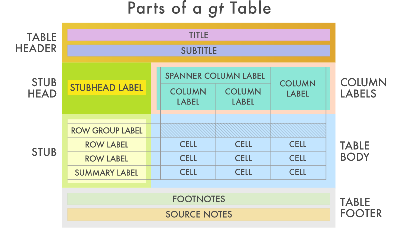

By itself it is not designed for displaying the typical “table 1” as seen in biomedical journals. That’s what the next package is for …

It’s still pretty useful:

```r
# install.packages("gt")
library(gt)

VAgrp <- sears %>%
  janitor::tabyl(VApriorityGrp) %>%
  janitor::adorn_pct_formatting() %>%
  gt()

# Create two additional footnotes, using the
# `columns` and `where` arguments of `data_cells()`
VAgrp <- VAgrp %>%
  tab_footnote(
    footnote = "Is it though?",
    locations = cells_body(
      columns = vars(VApriorityGrp),
      rows = 5)
  ) %>%
  tab_source_note(
    source_note = "VA Priority Group Information: https://www.va.gov/health-care/eligibility/priority-groups/"
  )

# Show the gt Table
VAgrp
```

| VApriorityGrp | n | percent |
| --- | --- | --- |
| Priority 1,4: High service-connected disability | 6415 | 21.9% |
| Priority 2,3,6: Low to moderate service-connected disability | 8710 | 29.8% |
| Priority 5: Low income | 9385 | 32.1% |
| Priority 7,8: No service-connected disability | 4298 | 14.7% |
| Priority: Unknown<sup>1</sup> | 434 | 1.5% |

VA Priority Group Information: https://www.va.gov/health-care/eligibility/priority-groups/  
<sup>*1*</sup> Is it though?

## gtsummary

As mentioned above, `gtsummary` is built on top of `gt` for display of journal-quality tables. And, it’s one of the easiest to use since it uses `tidyverse` principles.

```r
# install.packages("gtsummary")
library(gtsummary)

tab1 <- tab_vars %>%
  tbl_summary(
    by = CommCTS, # split table by group
    missing = "no" # don't list missing data separately
  ) %>%
  add_n() %>% # add column with total number of non-missing observations
  add_p() %>% # test if there's difference between groups
  bold_labels()

tab1
```

| **Characteristic** | **N** | **VA Only**, N = 23,330<sup>1</sup> | **VA+Community**, N = 5,912<sup>1</sup> | **p-value**<sup>2</sup> |
| --- | --- | --- | --- | --- |
| AgeAtIndexCTS | 29,236 | 59 (50, 66) | 57 (48, 63) | <0.001 |
| Sex | 29,236 |  |  | 0.8 |
| F |  | 2,425 (10%) | 622 (11%) |  |
| M |  | 20,899 (90%) | 5,290 (89%) |  |
| Race | 29,242 |  |  |  |
| AMERICAN INDIAN OR ALASKA NATIVE |  | 213 (0.9%) | 72 (1.2%) |  |
| ASIAN |  | 100 (0.4%) | 27 (0.5%) |  |
| BLACK OR AFRICAN AMERICAN |  | 3,097 (13%) | 585 (9.9%) |  |
| MULTI-RACIAL |  | 2 (<0.1%) | 1 (<0.1%) |  |
| NATIVE HAWAIIAN OR OTHER PACIFIC ISLANDER |  | 212 (0.9%) | 64 (1.1%) |  |
| WHITE |  | 18,664 (80%) | 4,879 (83%) |  |
| UNKNOWN |  | 1,042 (4.5%) | 284 (4.8%) |  |
| Eth_cat | 29,242 |  |  | 0.3 |
| Hispanic/Latino |  | 1,285 (5.5%) | 298 (5.0%) |  |
| Not Hispanic/Latino |  | 21,337 (91%) | 5,439 (92%) |  |
| Unspecificed/Unknown/Declined |  | 708 (3.0%) | 175 (3.0%) |  |
| charlsonCTS | 29,236 | 0 (0, 1) | 0 (0, 1) | 0.11 |
| charlsonCTS_cat | 29,236 |  |  | 0.013 |
| 0 |  | 17,077 (73%) | 4,371 (74%) |  |
| 1 |  | 3,339 (14%) | 884 (15%) |  |
| 2+ |  | 2,908 (12%) | 657 (11%) |  |
| Diabetes | 29,242 |  |  | <0.001 |
| No Diabetes Dx |  | 17,643 (76%) | 4,605 (78%) |  |
| Diabetes Dx |  | 5,687 (24%) | 1,307 (22%) |  |
| VApriorityGrp | 29,242 |  |  | <0.001 |
| Priority 1,4: High service-connected disability |  | 4,963 (21%) | 1,452 (25%) |  |
| Priority 2,3,6: Low to moderate service-connected disability |  | 6,747 (29%) | 1,963 (33%) |  |
| Priority 5: Low income |  | 7,619 (33%) | 1,766 (30%) |  |
| Priority 7,8: No service-connected disability |  | 3,599 (15%) | 699 (12%) |  |
| Priority: Unknown |  | 402 (1.7%) | 32 (0.5%) |  |
| dist_to_PCP_10 | 28,084 | 2 (1, 4) | 2 (1, 5) | <0.001 |

<sup>*1*</sup> Median (IQR); n (%) <sup>*2*</sup> Wilcoxon rank sum test; Pearson's Chi-squared test

`gtsummary` does not allow for multiple-comparisons adjustment, you’ll have to do it manually.

## flextable

`flextable` is used by some other packages for making tables so I’ll introduce it here and though it isn’t specifically for making a “table 1”. It can do one cool new trick and that’s conditional coloring of specific cells.

```r
sum_tab <- tab_vars %>%
  group_by(CommCTS) %>%
  select_if(is.numeric) %>%
  pivot_longer(
    cols = c("AgeAtIndexCTS", "charlsonCTS", "dist_to_PCP_10"),
    names_to = "Variable",
    values_to = "value"
  ) %>%
  na.omit() %>%
  group_by(CommCTS, Variable) %>%
  summarize(
    n      = n(),
    mean   = mean(value),
    sd     = sd(value),
    min    = min(value),
    Q1     = fivenum(value)[2],
    median = median(value),
    Q3     = fivenum(value)[4],
    max    = max(value)
  ) %>%
  mutate_if(is.numeric, round, 2)

sum_tab %>%
  arrange(Variable, CommCTS)
```

```
# A tibble: 6 × 10
# Groups:   CommCTS [2]
  CommCTS      Variable           n  mean    sd   min    Q1 median    Q3   max
  <fct>        <chr>          <dbl> <dbl> <dbl> <dbl> <dbl>  <dbl> <dbl> <dbl>
1 VA Only      AgeAtIndexCTS  23324 58.2  12.9  18.4  50.1   59.5  66     94.2
2 VA+Community AgeAtIndexCTS   5912 55.3  12.1  21.9  47.7   56.5  63.0   93.8
3 VA Only      charlsonCTS    23324  0.47  0.99  0     0      0     1     12
4 VA+Community charlsonCTS     5912  0.43  0.89  0     0      0     1      9
5 VA Only      dist_to_PCP_10 23145 11.8  39.4   0     0.72   1.68  4.15 829.
6 VA+Community dist_to_PCP_10  4939 13.0  43.9   0.01  0.8    2.13  5.2  863.
```

```r
# install.packages("flextable")
library(flextable)

ft <- flextable(sum_tab)
ft <- color(ft, i = ~ max > 90, j = ~ max, color = "red")
ft <- bg(ft,    i = ~ min <= 0, j = "median", bg = "#EFEF99")
ft
```

| CommCTS | Variable | n | mean | sd | min | Q1 | median | Q3 | max |
| --- | --- | --- | --- | --- | --- | --- | --- | --- | --- |
| VA Only | AgeAtIndexCTS | 23,324 | 58.15 | 12.93 | 18.42 | 50.14 | 59.48 | 66.00 | 94.25 |
| VA Only | charlsonCTS | 23,324 | 0.47 | 0.99 | 0.00 | 0.00 | 0.00 | 1.00 | 12.00 |
| VA Only | dist_to_PCP_10 | 23,145 | 11.75 | 39.35 | 0.00 | 0.72 | 1.68 | 4.15 | 829.28 |
| VA+Community | AgeAtIndexCTS | 5,912 | 55.31 | 12.12 | 21.92 | 47.66 | 56.51 | 62.99 | 93.76 |
| VA+Community | charlsonCTS | 5,912 | 0.43 | 0.89 | 0.00 | 0.00 | 0.00 | 1.00 | 9.00 |
| VA+Community | dist_to_PCP_10 | 4,939 | 12.95 | 43.90 | 0.01 | 0.80 | 2.13 | 5.20 | 862.73 |

## ttt

> `ttt` stands for “The Table Tool” (or, if you prefer “Tables! Tables! Tables!”).

This one may be the newest on this list. The author claims the approach used in development of the package was to simplify the coding interface when producing tables, I personally find the `formula` interface “limiting”. Here’s a few simple examples,

```r
library(ttt)

ttt(
  PCPtoCTRDiffDays ~ Diabetes | CommCTS,
  data = sears,
  lab = "Just Messin' around",
  render = median
)
```

| Diabetes | Just Messin' around VA Only | Just Messin' around VA+Community |
| --- | --- | --- |
| No Diabetes Dx | 178 | 376 |
| Diabetes Dx | 168 | 384 |

If something more specific is required, you must build a `render` function,

```r
rndr.meansd <- function(x) {
  table1::signif_pad(
    c(Mean = mean(x), SD = sd(x)),
    digits = 3
  )
}

ttt(
  PCPtoCTRDiffDays ~ Diabetes | CommCTS,
  data = sears,
  lab = "Just Messin' around",
  render = rndr.meansd,
  expand.along = "columns"
)
```

| Diabetes | Just Messin' around VA Only Mean | Just Messin' around VA Only SD | Just Messin' around VA+Community Mean | Just Messin' around VA+Community SD |
| --- | --- | --- | --- | --- |
| No Diabetes Dx | 426 | 555 | 699 | 705 |
| Diabetes Dx | 411 | 544 | 694 | 694 |

I would only use `ttt` for simple crosstabs of variables with low cardinality.

## jtools

`jtools` is mostly for modelling and tidy output of those results, in both table and plot formats. Warning: the example model build here will be overly simplified and probably misspecified.

```r
# install.packages("jtools")
library(jtools)
library(kableExtra) # helps for RMarkdown output!

mod <- glm(
  PCPtoCTRDiffDays ~ CommCTS + AgeAtIndexCTS + Diabetes,
  data = sears,
  family = Gamma(link = "log")
)

summ(mod, confint = TRUE)
```

| Observations | 29236 (6 missing obs. deleted) |
| --- | --- |
| Dependent variable | PCPtoCTRDiffDays |
| Type | Generalized linear model |
| Family | Gamma |
| Link | log |

| 𝛘²(3) | 1442.80 |
| --- | --- |
| Pseudo-R² (Cragg-Uhler) | 0.04 |
| Pseudo-R² (McFadden) | 0.00 |
| AIC | 417868.83 |
| BIC | 417910.25 |

|  | Est. | 2.5% | 97.5% | t val. | p |
| --- | --- | --- | --- | --- | --- |
| (Intercept) | 6.36 | 6.30 | 6.43 | 184.73 | 0.00 |
| CommCTSVA+Community | 0.49 | 0.45 | 0.53 | 26.74 | 0.00 |
| AgeAtIndexCTS | -0.01 | -0.01 | -0.00 | -9.45 | 0.00 |
| DiabetesDiabetes Dx | -0.00 | -0.04 | 0.03 | -0.11 | 0.91 |

Standard errors: MLE

It even allows the user to center and scale continuous variables on the fly,

```r
summ(mod, center = TRUE, scale = TRUE, n.sd = 2, confint = TRUE)
```

| Observations | 29236 (6 missing obs. deleted) |
| --- | --- |
| Dependent variable | PCPtoCTRDiffDays |
| Type | Generalized linear model |
| Family | Gamma |
| Link | log |

| 𝛘²(3) | 1442.80 |
| --- | --- |
| Pseudo-R² (Cragg-Uhler) | 0.04 |
| Pseudo-R² (McFadden) | 0.00 |
| AIC | 417868.83 |
| BIC | 417910.25 |

|  | Est. | 2.5% | 97.5% | t val. | p |
| --- | --- | --- | --- | --- | --- |
| (Intercept) | 6.05 | 6.03 | 6.06 | 655.23 | 0.00 |
| CommCTS | 0.49 | 0.45 | 0.53 | 26.74 | 0.00 |
| AgeAtIndexCTS | -0.14 | -0.17 | -0.11 | -9.45 | 0.00 |
| Diabetes | -0.00 | -0.04 | 0.03 | -0.11 | 0.91 |

Standard errors: MLE; Continuous predictors are mean-centered and scaled by 2 s.d.

The function `export_summs` is what you’ll want to use to export results for dissemination to others.

```r
export_summs(
  mod,
  scale = TRUE,
  error_format = "[{conf.low}, {conf.high}]"
)
```

[output not shown]

Watch out for the hidden dependency when using `export_summs`, you’ll want to run `install.packages("huxtable")`

And I’m not doing it here but the following code shows you how to export to MS Word

```r
export_summs(
  mod,
  scale = TRUE,
  error_format = "[{conf.low}, {conf.high}]",
  to.file = "docx",
  file.name = "results/Gamma_model.docx"
)
```

And here are some of the plots

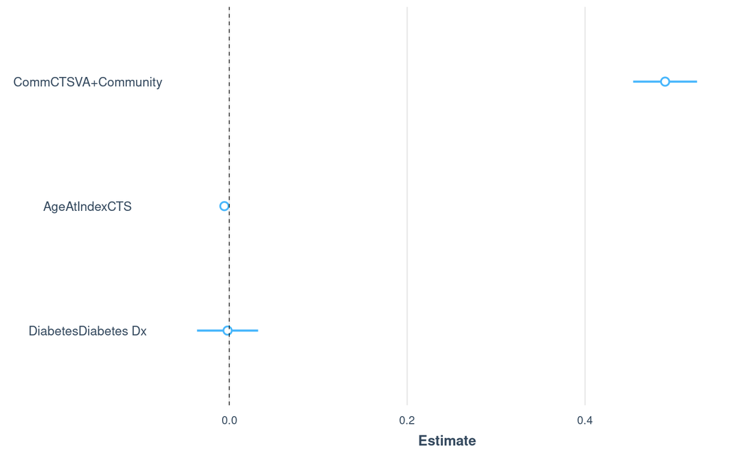

```r
plot_summs(mod)
```

More hidden dependencies! `install.packages(c("ggstance", "broom.mixed"))`

scaled with 80% confidence intervals overlaid

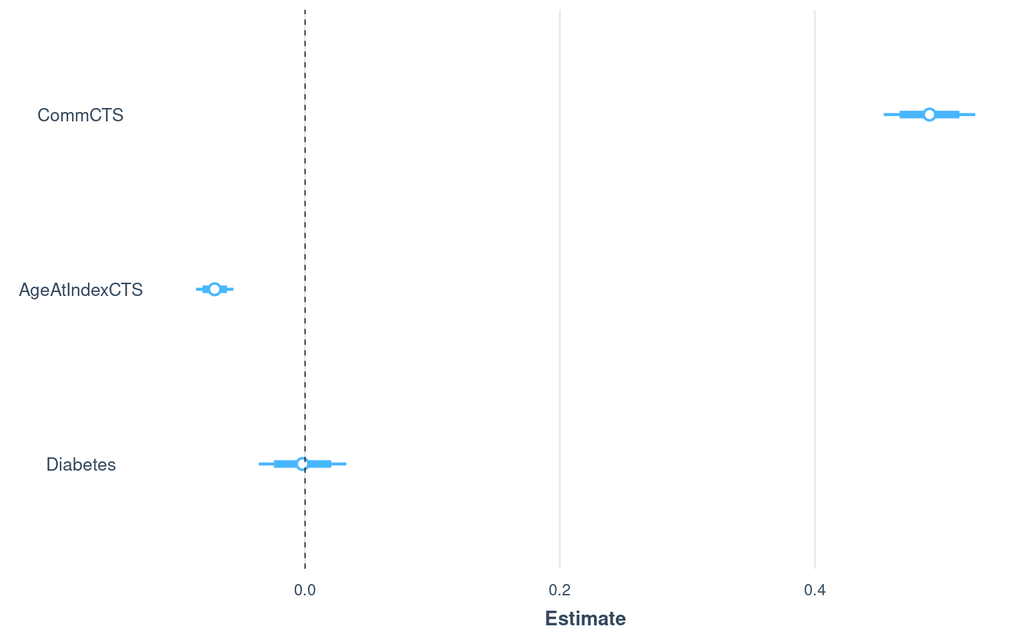

```r
plot_summs(mod, scale = TRUE, inner_ci_level = 0.8)
```

## sj-family

The `sj` family of functions is becoming my favorite for it’s flexibility across multiple frameworks of modeling, including Bayesian models and survey building tasks. The packages we’ll use here are `sjmisc`, `sjlabelled`, and `sjPlot`.

```r
# install.packages(c("sjplot", "sjmisc", "sjlabelled"))
library(sjlabelled)
library(sjmisc)
library(sjPlot)

sjPlot::tab_model(mod)
```

|  | PC Pto CTR Diff Days |  |  |
| --- | --- | --- | --- |
| Predictors | Estimates | CI | p |
| (Intercept) | 580.75 | 540.33 – 624.30 | **<0.001** |
| CommCTS [VA+Community] | 1.63 | 1.57 – 1.69 | **<0.001** |
| AgeAtIndexCTS | 0.99 | 0.99 – 1.00 | **<0.001** |
| Diabetes [Diabetes Dx] | 1.00 | 0.96 – 1.03 | 0.912 |
| Observations | 29236 |  |  |
| R<sup>2</sup> Nagelkerke | 0.064 |  |  |

Notice that `tab_model` will try to “fix” the outcome/dependent variable name - “PC Pto CTR Diff Days” - it got some of it right. There’s an argument to turn this option off.

If instead the model we built incorporated a varying intercept for each `Sta3n`, `sjPlot` can handle that as well,

```r
library(lme4)

mod2 <- glmer(
  PCPtoCTRDiffDays ~ CommCTS + AgeAtIndexCTS + Diabetes + (1 | Sta3n),
  data = sears %>% filter(!(Sta3n == "358")),
  family = Gamma(link = "log")
)

tab_model(mod2)
```

|  | PC Pto CTR Diff Days |  |  |
| --- | --- | --- | --- |
| Predictors | Estimates | CI | p |
| (Intercept) | 570.50 | 531.39 – 612.49 | **<0.001** |
| CommCTS [VA+Community] | 1.76 | 1.71 – 1.82 | **<0.001** |
| AgeAtIndexCTS | 0.99 | 0.99 – 1.00 | **<0.001** |
| Diabetes [Diabetes Dx] | 0.99 | 0.96 – 1.02 | 0.549 |
| Random Effects |  |  |  |
| σ<sup>2</sup> | 1.57 |  |  |
| τ<sub>00</sub> <sub>Sta3n</sub> | 0.06 |  |  |
| ICC | 0.04 |  |  |
| N <sub>Sta3n</sub> | 129 |  |  |
| Observations | 29232 |  |  |
| Marginal R<sup>2</sup> / Conditional R<sup>2</sup> | 0.035 / 0.070 |  |  |

This model had convergence issues, but that’s not really something we care about here.

You can even place models side-by-side, for comparison purposes

```r
tab_model(mod, mod2)
```

|  | PC Pto CTR Diff Days |  |  | PC Pto CTR Diff Days |  |  |
| --- | --- | --- | --- | --- | --- | --- |
| Predictors | Estimates | CI | p | Estimates | CI | p |
| (Intercept) | 580.75 | 540.33 – 624.30 | **<0.001** | 570.50 | 531.39 – 612.49 | **<0.001** |
| CommCTS [VA+Community] | 1.63 | 1.57 – 1.69 | **<0.001** | 1.76 | 1.71 – 1.82 | **<0.001** |
| AgeAtIndexCTS | 0.99 | 0.99 – 1.00 | **<0.001** | 0.99 | 0.99 – 1.00 | **<0.001** |
| Diabetes [Diabetes Dx] | 1.00 | 0.96 – 1.03 | 0.912 | 0.99 | 0.96 – 1.02 | 0.549 |
| Random Effects |  |  |  |  |  |  |
| σ<sup>2</sup> |  |  |  | 1.57 |  |  |
| τ<sub>00</sub> |  |  |  | 0.06 <sub>Sta3n</sub> |  |  |
| ICC |  |  |  | 0.04 |  |  |
| N |  |  |  | 129 <sub>Sta3n</sub> |  |  |
| Observations | 29236 |  |  | 29232 |  |  |
| R<sup>2</sup> Nagelkerke | 0.064 |  |  | 0.035 / 0.070 |  |  |

As usual, there are many ways to change the overall appearance of the output, refer to the vignettes for details.

## finalfit

This ones been floating around for years and it can be pretty cool for showing both model summaries and table 1 summaries. The syntax is similar to `tableone`.

```r
# install.packages("finalfit")
library(finalfit)

# Table 1 - Patient demographics by variable of interest ----
explanatory <- c(cont, cate)
dependent <- strata

tab_vars %>%
  summary_factorlist(
    dependent,
    explanatory,
    p = TRUE,
    add_dependent_label = TRUE
  ) %>%
  knitr::kable(
    row.names = FALSE,
    align = c("l", "l", "r", "r", "r")
  )
```

| Dependent: CommCTS |  | VA Only | VA+Community | p |
| --- | --- | --- | --- | --- |
| AgeAtIndexCTS | Mean (SD) | 58.1 (12.9) | 55.3 (12.1) | <0.001 |
| dist_to_PCP_10 | Mean (SD) | 11.7 (39.3) | 12.9 (43.9) | 0.056 |
| Sex | F | 2425 (10.4) | 622 (10.5) | 0.799 |
|  | M | 20899 (89.6) | 5290 (89.5) |  |
| Race | AMERICAN INDIAN OR ALASKA NATIVE | 213 (0.9) | 72 (1.2) | <0.001 |
|  | ASIAN | 100 (0.4) | 27 (0.5) |  |
|  | BLACK OR AFRICAN AMERICAN | 3097 (13.3) | 585 (9.9) |  |
|  | MULTI-RACIAL | 2 (0.0) | 1 (0.0) |  |
|  | NATIVE HAWAIIAN OR OTHER PACIFIC ISLANDER | 212 (0.9) | 64 (1.1) |  |
|  | WHITE | 18664 (80.0) | 4879 (82.5) |  |
|  | UNKNOWN | 1042 (4.5) | 284 (4.8) |  |
| Eth_cat | Hispanic/Latino | 1285 (5.5) | 298 (5.0) | 0.343 |
|  | Not Hispanic/Latino | 21337 (91.5) | 5439 (92.0) |  |
|  | Unspecificed/Unknown/Declined | 708 (3.0) | 175 (3.0) |  |
| charlsonCTS_cat | 0 | 17077 (73.2) | 4371 (73.9) | 0.013 |
|  | 1 | 3339 (14.3) | 884 (15.0) |  |
|  | 2+ | 2908 (12.5) | 657 (11.1) |  |
| Diabetes | No Diabetes Dx | 17643 (75.6) | 4605 (77.9) | <0.001 |
|  | Diabetes Dx | 5687 (24.4) | 1307 (22.1) |  |
| VApriorityGrp | Priority 1,4: High service-connected disability | 4963 (21.3) | 1452 (24.6) | <0.001 |
|  | Priority 2,3,6: Low to moderate service-connected disability | 6747 (28.9) | 1963 (33.2) |  |
|  | Priority 5: Low income | 7619 (32.7) | 1766 (29.9) |  |
|  | Priority 7,8: No service-connected disability | 3599 (15.4) | 699 (11.8) |  |
|  | Priority: Unknown | 402 (1.7) | 32 (0.5) |  |

Or, for logistic regression purposes (among others). Keep in mind, this model isn’t going to make any sense, it’s just an example.

```r
tab_vars %>%
  finalfit(
    dependent,
    explanatory[-8] # odd warning about `:` not allowed in factor names
  ) %>%
  knitr::kable(
    row.names = FALSE,
    align = c("l", "l", "r", "r", "r", "r")
  )
```

Dependent: CommCTS

VA Only

VA+Community

OR (univariable)

OR (multivariable)

AgeAtIndexCTS

Mean (SD)

58.1 (12.9)

55.3 (12.1)

0.98 (0.98-0.99, p<0.001)

0.98 (0.98-0.98, p<0.001)

dist_to_PCP_10

Mean (SD)

11.7 (39.3)

12.9 (43.9)

1.00 (1.00-1.00, p=0.057)

1.00 (1.00-1.00, p=0.385)

Sex

F

2425 (79.6)

622 (20.4)

M

20899 (79.8)

5290 (20.2)

0.99 (0.90-1.08, p=0.781)

1.19 (1.08-1.33, p=0.001)

Race

AMERICAN INDIAN OR ALASKA NATIVE

213 (74.7)

72 (25.3)

ASIAN

100 (78.7)

27 (21.3)

0.80 (0.48-1.31, p=0.380)

0.58 (0.32-1.02, p=0.067)

BLACK OR AFRICAN AMERICAN

3097 (84.1)

585 (15.9)

0.56 (0.42-0.74, p<0.001)

0.56 (0.41-0.77, p<0.001)

MULTI-RACIAL

2 (66.7)

1 (33.3)

1.48 (0.07-15.66, p=0.751)

0.00 (NA-44.31, p=0.911)

NATIVE HAWAIIAN OR OTHER PACIFIC ISLANDER

212 (76.8)

64 (23.2)

0.89 (0.61-1.31, p=0.567)

0.75 (0.48-1.17, p=0.208)

WHITE

18664 (79.3)

4879 (20.7)

0.77 (0.59-1.02, p=0.061)

0.85 (0.64-1.15, p=0.281)

UNKNOWN

1042 (78.6)

284 (21.4)

0.81 (0.60-1.09, p=0.156)

0.88 (0.64-1.24, p=0.464)

Eth_cat

Hispanic/Latino

1285 (81.2)

298 (18.8)

Not Hispanic/Latino

21337 (79.7)

5439 (20.3)

1.10 (0.97-1.25, p=0.152)

1.21 (1.05-1.40, p=0.008)

Unspecificed/Unknown/Declined

708 (80.2)

175 (19.8)

1.07 (0.86-1.31, p=0.548)

1.10 (0.87-1.40, p=0.420)

charlsonCTS_cat

0

17077 (79.6)

4371 (20.4)

1

3339 (79.1)

884 (20.9)

1.03 (0.95-1.12, p=0.415)

1.17 (1.06-1.27, p=0.001)

2+

2908 (81.6)

657 (18.4)

0.88 (0.81-0.97, p=0.007)

1.01 (0.91-1.12, p=0.802)

Diabetes

No Diabetes Dx

17643 (79.3)

4605 (20.7)

Diabetes Dx

5687 (81.3)

1307 (18.7)

0.88 (0.82-0.94, p<0.001)

0.95 (0.88-1.03, p=0.219)

## DIY

Sometimes you just have to do it yourself with `knitr`, `kable` and `kableExtra`. First, make helper functions,

```r
bootstrap_options <- c("striped", "hover", "condensed")

tableStyle <- function(t,
                       boot_opt = bootstrap_options,
                       full_width = TRUE,
                       digits = 2) {

  t %>%
    mutate_if(is.numeric, round, digits = digits) %>%
    knitr::kable() %>%
    kableExtra::kable_styling(
      bootstrap_options = boot_opt,
      full_width = full_width
    )
}

scrollTable <- function(t,
                        boot_opt = bootstrap_options,
                        full_width = TRUE,
                        width = "600px", height = "400px",
                        digits = 2) {
  t %>%
    mutate_if(is.numeric, round, digits = digits) %>%
    knitr::kable() %>%
    kableExtra::kable_styling(
      bootstrap_options = bootstrap_options,
      full_width = full_width
    ) %>%
    kableExtra::scroll_box(width = width, height = height)
}
```

We’ll use the summary table from above

```r
sum_tab %>%
  tableStyle()
```

| CommCTS | Variable | n | mean | sd | min | Q1 | median | Q3 | max |
| --- | --- | --- | --- | --- | --- | --- | --- | --- | --- |
| VA Only | AgeAtIndexCTS | 23324 | 58.15 | 12.93 | 18.42 | 50.14 | 59.48 | 66.00 | 94.25 |
| VA Only | charlsonCTS | 23324 | 0.47 | 0.99 | 0.00 | 0.00 | 0.00 | 1.00 | 12.00 |
| VA Only | dist_to_PCP_10 | 23145 | 11.75 | 39.35 | 0.00 | 0.72 | 1.68 | 4.15 | 829.28 |
| VA+Community | AgeAtIndexCTS | 5912 | 55.31 | 12.12 | 21.92 | 47.66 | 56.51 | 62.99 | 93.76 |
| VA+Community | charlsonCTS | 5912 | 0.43 | 0.89 | 0.00 | 0.00 | 0.00 | 1.00 | 9.00 |
| VA+Community | dist_to_PCP_10 | 4939 | 12.95 | 43.90 | 0.01 | 0.80 | 2.13 | 5.20 | 862.73 |

Or when things start to get too long you can embed them into a scrolling table (only HTML output though).

```r
library(correlation)
library(see)

tab_vars %>%
  select(all_of(explanatory)) %>%
  na.omit() %>%
  correlation(include_factors = TRUE, method = "auto") %>%
  scrollTable(digits = 3, width = "900px", height = "800px")
```

| Parameter1 | Parameter2 | r | CI | CI_low | CI_high | t | df_error | p | Method | n_Obs |
| --- | --- | --- | --- | --- | --- | --- | --- | --- | --- | --- |
| AgeAtIndexCTS | dist_to_PCP_10 | -0.073 | 0.95 | -0.085 | -0.062 | -12.312 | 28076 | 0.000 | Pearson correlation | 28078 |
| AgeAtIndexCTS | Sex.F | -0.265 | 0.95 | -0.276 | -0.254 | -45.990 | 28076 | 0.000 | Point-biserial correlation | 28078 |
| AgeAtIndexCTS | Sex.M | 0.265 | 0.95 | 0.254 | 0.276 | 45.990 | 28076 | 0.000 | Point-biserial correlation | 28078 |
| AgeAtIndexCTS | Race.AMERICAN INDIAN OR ALASKA NATIVE | -0.025 | 0.95 | -0.037 | -0.013 | -4.218 | 28076 | 0.002 | Point-biserial correlation | 28078 |
| AgeAtIndexCTS | Race.ASIAN | -0.041 | 0.95 | -0.053 | -0.030 | -6.950 | 28076 | 0.000 | Point-biserial correlation | 28078 |
| AgeAtIndexCTS | Race.BLACK OR AFRICAN AMERICAN | -0.084 | 0.95 | -0.096 | -0.073 | -14.188 | 28076 | 0.000 | Point-biserial correlation | 28078 |
| AgeAtIndexCTS | Race.MULTI-RACIAL | -0.013 | 0.95 | -0.024 | -0.001 | -2.144 | 28076 | 1.000 | Point-biserial correlation | 28078 |
| AgeAtIndexCTS | Race.NATIVE HAWAIIAN OR OTHER PACIFIC ISLANDER | -0.014 | 0.95 | -0.026 | -0.002 | -2.369 | 28076 | 0.672 | Point-biserial correlation | 28078 |
| AgeAtIndexCTS | Race.WHITE | 0.087 | 0.95 | 0.076 | 0.099 | 14.667 | 28076 | 0.000 | Point-biserial correlation | 28078 |
| AgeAtIndexCTS | Race.UNKNOWN | 0.001 | 0.95 | -0.011 | 0.012 | 0.107 | 28076 | 1.000 | Point-biserial correlation | 28078 |
| AgeAtIndexCTS | Eth_cat.Hispanic/Latino | -0.068 | 0.95 | -0.080 | -0.056 | -11.430 | 28076 | 0.000 | Point-biserial correlation | 28078 |
| AgeAtIndexCTS | Eth_cat.Not Hispanic/Latino | 0.050 | 0.95 | 0.038 | 0.061 | 8.311 | 28076 | 0.000 | Point-biserial correlation | 28078 |
| AgeAtIndexCTS | Eth_cat.Unspecificed/Unknown/Declined | 0.010 | 0.95 | -0.002 | 0.022 | 1.666 | 28076 | 1.000 | Point-biserial correlation | 28078 |
| AgeAtIndexCTS | charlsonCTS_cat.0 | -0.198 | 0.95 | -0.209 | -0.187 | -33.811 | 28076 | 0.000 | Point-biserial correlation | 28078 |
| AgeAtIndexCTS | charlsonCTS_cat.1 | 0.092 | 0.95 | 0.081 | 0.104 | 15.544 | 28076 | 0.000 | Point-biserial correlation | 28078 |
| AgeAtIndexCTS | charlsonCTS_cat.2+ | 0.168 | 0.95 | 0.157 | 0.179 | 28.555 | 28076 | 0.000 | Point-biserial correlation | 28078 |
| AgeAtIndexCTS | Diabetes.No Diabetes Dx | -0.194 | 0.95 | -0.205 | -0.183 | -33.110 | 28076 | 0.000 | Point-biserial correlation | 28078 |
| AgeAtIndexCTS | Diabetes.Diabetes Dx | 0.194 | 0.95 | 0.183 | 0.205 | 33.110 | 28076 | 0.000 | Point-biserial correlation | 28078 |
| AgeAtIndexCTS | VApriorityGrp.Priority 1,4: High service-connected disability | -0.091 | 0.95 | -0.102 | -0.079 | -15.278 | 28076 | 0.000 | Point-biserial correlation | 28078 |
| AgeAtIndexCTS | VApriorityGrp.Priority 2,3,6: Low to moderate service-connected disability | -0.090 | 0.95 | -0.102 | -0.078 | -15.146 | 28076 | 0.000 | Point-biserial correlation | 28078 |
| AgeAtIndexCTS | VApriorityGrp.Priority 5: Low income | 0.067 | 0.95 | 0.056 | 0.079 | 11.322 | 28076 | 0.000 | Point-biserial correlation | 28078 |
| AgeAtIndexCTS | VApriorityGrp.Priority 7,8: No service-connected disability | 0.164 | 0.95 | 0.153 | 0.176 | 27.904 | 28076 | 0.000 | Point-biserial correlation | 28078 |
| AgeAtIndexCTS | VApriorityGrp.Priority: Unknown | -0.091 | 0.95 | -0.102 | -0.079 | -15.271 | 28076 | 0.000 | Point-biserial correlation | 28078 |
| dist_to_PCP_10 | Sex.F | 0.037 | 0.95 | 0.025 | 0.049 | 6.233 | 28076 | 0.000 | Point-biserial correlation | 28078 |
| dist_to_PCP_10 | Sex.M | -0.037 | 0.95 | -0.049 | -0.025 | -6.233 | 28076 | 0.000 | Point-biserial correlation | 28078 |
| dist_to_PCP_10 | Race.AMERICAN INDIAN OR ALASKA NATIVE | -0.005 | 0.95 | -0.016 | 0.007 | -0.768 | 28076 | 1.000 | Point-biserial correlation | 28078 |
| dist_to_PCP_10 | Race.ASIAN | 0.068 | 0.95 | 0.056 | 0.080 | 11.404 | 28076 | 0.000 | Point-biserial correlation | 28078 |
| dist_to_PCP_10 | Race.BLACK OR AFRICAN AMERICAN | -0.013 | 0.95 | -0.024 | -0.001 | -2.108 | 28076 | 1.000 | Point-biserial correlation | 28078 |
| dist_to_PCP_10 | Race.MULTI-RACIAL | -0.002 | 0.95 | -0.014 | 0.009 | -0.378 | 28076 | 1.000 | Point-biserial correlation | 28078 |
| dist_to_PCP_10 | Race.NATIVE HAWAIIAN OR OTHER PACIFIC ISLANDER | 0.035 | 0.95 | 0.023 | 0.046 | 5.815 | 28076 | 0.000 | Point-biserial correlation | 28078 |

[output cut: 246 more lines]

# Even More …

This list was far from exhaustive, these are just the ones I’ve found useful here and there. Here is a more complete, yet still not exhaustive list: `huxtable`, `htmlTable`, `tableHTML`, `ztable`, `formattable`, `pixiedust`, `basictabler`, `mmtable2`, `DT`, `tables`, `xtable`, …